# Impact of severe weather events on public health and the economy

=====================================================================================================================================

# Synopsis

This is the second course project for the Reproducible Research course, part of Coursera’s Data Science Specialization offered through Johns Hopkins University.

Severe weather events can cause drastic public health and economic consequences; thus, tracking these events and their outcomes is key to addressing these impacts. This project utilizes the U.S. National Oceanic and Atmospheric Administration’s (NOAA) storm database, which tracks major weather events in the U.S. and associated variables, including: when and where they occur, total population fatalities, total population injuries, resulting property damage, and resulting agricultural damage. The following analysis demonstrates that tornadoes have the most severe impact on population health (measured by fatalities and injuries), while floods have the most severe economic consequences (measured by property and crop damage).

=====================================================================================================================================

# Libraries

```r
library(tidyverse)
library(magrittr)
```

=====================================================================================================================================

# Data processing

### Data description

The data utlized in this experiment can be found on the course website, or at [this link](https://d396qusza40orc.cloudfront.net/repdata%2Fdata%2FStormData.csv.bz2).

Data documentation is available at the National Weather Service [Storm Data Documentation](https://d396qusza40orc.cloudfront.net/repdata%2Fpeer2_doc%2Fpd01016005curr.pdf) and the National Climatic Data Center Storm Events [FAQ](https://d396qusza40orc.cloudfront.net/repdata%2Fpeer2_doc%2FNCDC%20Storm%20Events-FAQ%20Page.pdf).

The events in the database start in the year 1950 and end in November 2011. Of note: in the earlier years of the database there are generally fewer events recorded, most likely due to a lack of good records. More recent years should be considered more complete.

### Load data

Data can be downloaded and loaded into the R environment using the following commands:

```r
download.file("https://d396qusza40orc.cloudfront.net/repdata%2Fdata%2FStormData.csv.bz2",
              destfile = "Reproducible Research/Course project 2/StormData.csv.bz2")

df_stormdata <- read.csv(bzfile("Reproducible Research/Course project 2/StormData.csv.bz2"), header = TRUE) %>%
       as_tibble()
```

Where destfile is your local working directory. Also, I’m a big fan of tidyverse, so my go-to whenever I download data is to create a tibble.

However, because this takes a while to do, and for ease of use, I saved the dataframe as an Rdata object in my working directory, and can simply load it using the load() command. That way, data won’t be re-downloaded and re-loaded every time you knit the Rmd file.

```r
load("df_stormdata.Rdata")
```

### Extract variables of interest

As stated in the synopsis, we are interested in variables that address population health and economic consequences. These factors are represented in the data by the following:

Events:

- EVTYPE = weather event

Economic:

- PROPDMG = approximate property damages
- PROPDMGEXP = units for property damage value
- CROPDMG = approximate crop damages
- CROPDMGEXP = units for crop damage value

Health:

- FATALITIES = approximate number of deaths
- INJURIES = approximate number of injuries

Let’s extract these variables from the original dataset:

```r
df_stormdata2 <- df_stormdata %>% select(EVTYPE, PROPDMG, PROPDMGEXP, CROPDMG, CROPDMGEXP, FATALITIES, INJURIES)
```

### Population health data

Now let’s check out the population health data in terms of fatalities and injuries. To assess severity of impact, we can simply add the total fatalities and injuries for each weather event. Here I show the top 10 most harmful for each category. Dataframes combined for future plotting ease.

First we can add up fatalities by event:

```r
df_fatalities <- df_stormdata2 %>%

       group_by(EVTYPE) %>%
       summarise(sum(FATALITIES)) %>%
       rename("total" = "sum(FATALITIES)") %>%
       arrange(-total) %>%
       head(10) %>%
       mutate(type = "Fatalities")
```

Then injuries:

```r
df_injuries <- df_stormdata2 %>%

       group_by(EVTYPE) %>%
       summarise(sum(INJURIES)) %>%
       rename("total" = "sum(INJURIES)") %>%
       arrange(-total) %>%
       head(10) %>%
       mutate(type = "Injuries")
```

Then we combine:

```r
df_health <-  rbind(df_fatalities, df_injuries)

df_health
```

```
## # A tibble: 20 x 3
##    EVTYPE            total type
##    <fct>             <dbl> <chr>
##  1 TORNADO            5633 Fatalities
##  2 EXCESSIVE HEAT     1903 Fatalities
##  3 FLASH FLOOD         978 Fatalities
##  4 HEAT                937 Fatalities
##  5 LIGHTNING           816 Fatalities
##  6 TSTM WIND           504 Fatalities
##  7 FLOOD               470 Fatalities
##  8 RIP CURRENT         368 Fatalities
##  9 HIGH WIND           248 Fatalities
## 10 AVALANCHE           224 Fatalities
## 11 TORNADO           91346 Injuries
## 12 TSTM WIND          6957 Injuries
## 13 FLOOD              6789 Injuries
## 14 EXCESSIVE HEAT     6525 Injuries
## 15 LIGHTNING          5230 Injuries
## 16 HEAT               2100 Injuries
## 17 ICE STORM          1975 Injuries
## 18 FLASH FLOOD        1777 Injuries
## 19 THUNDERSTORM WIND  1488 Injuries
## 20 HAIL               1361 Injuries
```

### Economic consequences data

The economic data is a little bit trickier to add up. The “DMGEXP” columns for both property and crop damages include a number, letter, or symbol indicated the power to which the numeric value listed should be raised to. This will give us the total cost in USD. We can address this by creating a new column that gives the associated multiplier for both property and crop damages, then multiply this by the numeric value listed.

```r
df_stormdata3 <- df_stormdata2 %>%

       mutate(prop_multiplier = case_when(


              df_stormdata2$PROPDMGEXP == "" ~ 1,
              df_stormdata2$PROPDMGEXP == "-" ~ 0,
              df_stormdata2$PROPDMGEXP == "+" ~ 0,
              df_stormdata2$PROPDMGEXP == "0" ~ 0,
              df_stormdata2$PROPDMGEXP == "2" ~ 100,
              df_stormdata2$PROPDMGEXP == "3" ~ 1000,
              df_stormdata2$PROPDMGEXP == "4" ~ 10000,
              df_stormdata2$PROPDMGEXP == "5" ~ 1e+05,
              df_stormdata2$PROPDMGEXP == "6" ~ 1e+06,
              df_stormdata2$PROPDMGEXP == "7" ~ 1e+07,
              df_stormdata2$PROPDMGEXP == "B" ~ 1e+09,
              df_stormdata2$PROPDMGEXP == "h" ~ 100,
              df_stormdata2$PROPDMGEXP == "H" ~ 100,
              df_stormdata2$PROPDMGEXP == "K" ~ 1000,
              df_stormdata2$PROPDMGEXP == "m" ~ 1e+06,
              df_stormdata2$PROPDMGEXP == "M" ~ 1e+06


       )) %>%

       mutate(crop_multiplier = case_when(


              df_stormdata2$CROPDMGEXP == "" ~ 1,
              df_stormdata2$CROPDMGEXP == "-" ~ 0,
              df_stormdata2$CROPDMGEXP == "+" ~ 0,
              df_stormdata2$CROPDMGEXP == "0" ~ 0,
              df_stormdata2$CROPDMGEXP == "2" ~ 100,
              df_stormdata2$CROPDMGEXP == "3" ~ 1000,
              df_stormdata2$CROPDMGEXP == "4" ~ 10000,
              df_stormdata2$CROPDMGEXP == "5" ~ 1e+05,
              df_stormdata2$CROPDMGEXP == "6" ~ 1e+06,
              df_stormdata2$CROPDMGEXP == "7" ~ 1e+07,
              df_stormdata2$CROPDMGEXP == "B" ~ 1e+09,
              df_stormdata2$CROPDMGEXP == "h" ~ 100,
              df_stormdata2$CROPDMGEXP == "H" ~ 100,
              df_stormdata2$CROPDMGEXP == "K" ~ 1000,
              df_stormdata2$CROPDMGEXP == "m" ~ 1e+06,
              df_stormdata2$CROPDMGEXP == "M" ~ 1e+06


       ))
```

Now, we can add up property damages:

```r
df_propdmg <- df_stormdata3 %>%

       mutate(propdmgval = PROPDMG * prop_multiplier) %>%
       group_by(EVTYPE) %>%
       summarise(sum(propdmgval)) %>%
       rename("total" = "sum(propdmgval)") %>%
       arrange(-total) %>%
       head(10) %>%
       mutate(type = "Property")
```

And crop damages:

```r
df_cropdmg <- df_stormdata3 %>%

       mutate(cropdmgval = CROPDMG * crop_multiplier) %>%
       group_by(EVTYPE) %>%
       summarise(sum(cropdmgval)) %>%
       rename("total" = "sum(cropdmgval)") %>%
       arrange(-total) %>%
       head(10) %>%
       mutate(type = "Crop")
```

And once again combine for plotting purposes:

```r
df_econ = rbind(df_propdmg, df_cropdmg)

df_econ
```

```
## # A tibble: 20 x 3
##    EVTYPE                   total type
##    <fct>                    <dbl> <chr>
##  1 FLOOD             144657709807 Property
##  2 HURRICANE/TYPHOON  69305840000 Property
##  3 STORM SURGE        43323536000 Property
##  4 HURRICANE          11868319010 Property
##  5 TROPICAL STORM      7703890550 Property
##  6 WINTER STORM        6688497250 Property
##  7 HIGH WIND           5270046260 Property
##  8 RIVER FLOOD         5118945500 Property
##  9 WILDFIRE            4765114000 Property
## 10 STORM SURGE/TIDE    4641188000 Property
## 11 DROUGHT            13972566000 Crop
## 12 FLOOD               5661968450 Crop
## 13 RIVER FLOOD         5029459000 Crop
## 14 ICE STORM           5022113500 Crop
## 15 HURRICANE           2741910000 Crop
## 16 HURRICANE/TYPHOON   2607872800 Crop
## 17 FLASH FLOOD         1421317100 Crop
## 18 EXTREME COLD        1292973000 Crop
## 19 FROST/FREEZE        1094086000 Crop
## 20 HEAVY RAIN           733399800 Crop
```

=====================================================================================================================================

# Results

1. Across the US, which types of events are most harmful with respect to population health?

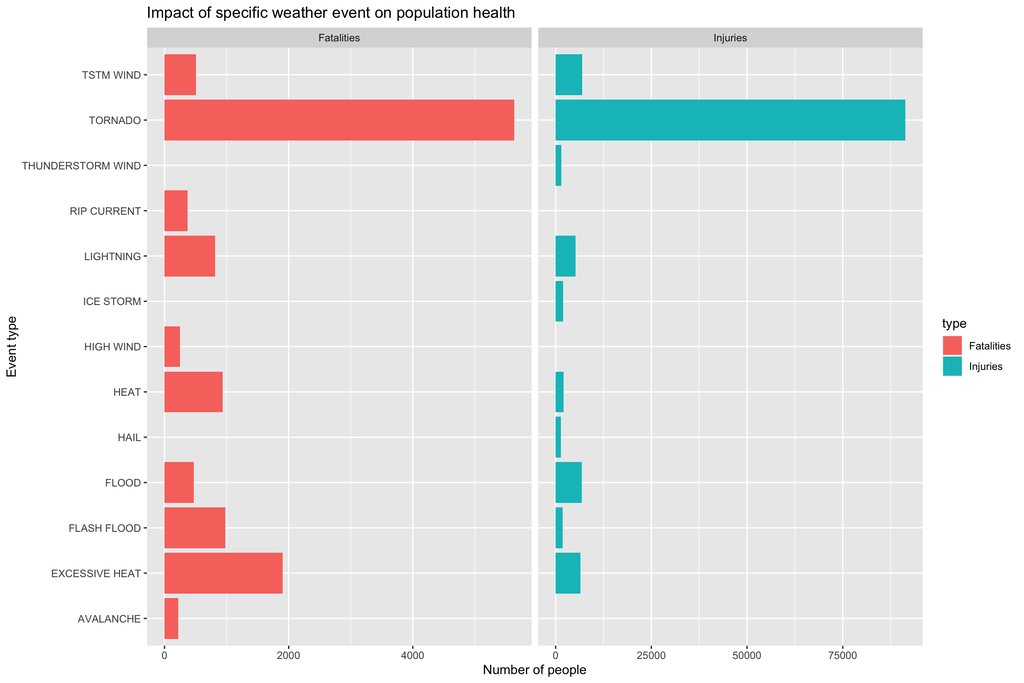

```r
df_health %>% ggplot(aes(x = EVTYPE, y = total, fill = type)) +

       geom_bar(stat = "identity") +
       facet_grid(~type, scales = "free") +
       coord_flip() +
       xlab("Event type") +
       ylab("Number of people") +
       ggtitle("Impact of specific weather event on population health")
```

Tornadoes are clearly most harmful to population health in terms of injuries and fatalities.

2. Across the US, which types of events have the greatest economic consequences??

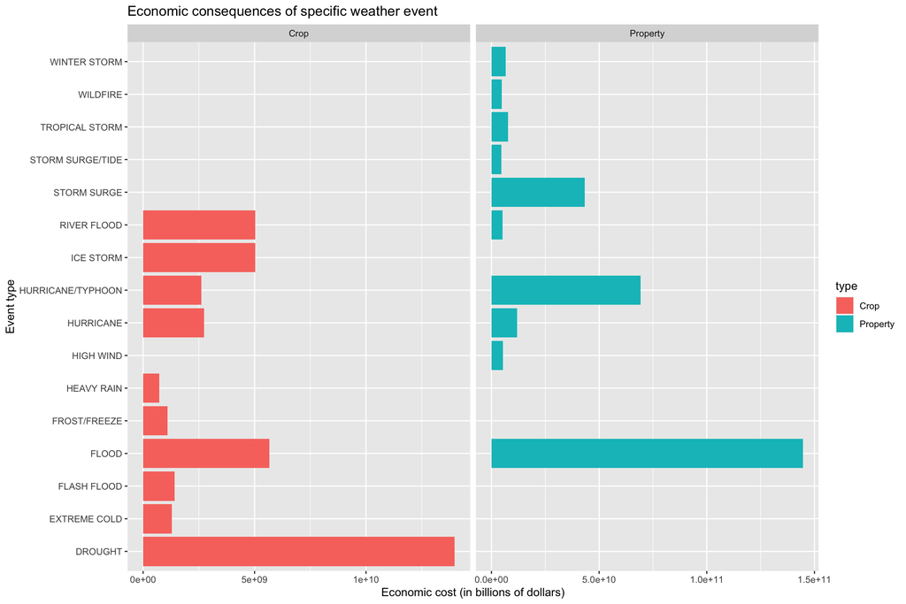

```r
df_econ %>% ggplot(aes(x = EVTYPE, y = total, fill = type)) +

       geom_bar(stat = "identity") +
       facet_grid(~type, scales = "free") +
       coord_flip() +
       xlab("Event type") +
       ylab("Economic cost (in billions of dollars)") +
       ggtitle("Economic consequences of specific weather event")
```